# Częstość zachorowań na raka piersi w Polsce w latach 2010-2012

Alicja Gosiewska, Gabriela Jaworska, Izabela Lis

12 czerwca 2016

# Wstęp

Chociaż przyczyny rozwoju raka piersi nie są dokładnie znane, istnieje kilka czynników, które mogą zwiększać ryzyko jego wystąpienia. Do najbardziej istotnych zalicza się czynniki dziedziczne, które znacznie zwiększają prawdopodobieństwo choroby. Oprócz czynników genetycznych znaczacą rolę odgrywa płeć (u mężczyzn zdarza się 100 razy rzadziej), wiek, liczba potomstwa, alkohol oraz otyłość. Badania dowodzą, że na zwiększenie ryzyka wystąpienia raka piersi mają wpływ również czynniki środowiskowe. Najczęściej rak piersi występuje w Ameryce Północnej i krajach Europy Zachodniej, czyli w krajach wysoko uprzemysłowionych. Najrzadziej natomiast w Japonii i Chinach.

W naszych zbiorze danych, dla każdego przypadku zachorowania dysponujemy takimi informacjami jak: płeć, przedział wiekowy oraz powiat. Wykorzystując ostatnią informację postanowiłyśmy dodać do modelu zmienną ciągłą stopień urbanizacji, uzyskaną ze strony GUS. Ponieważ dla każdego przypadku choroby znamy powiat występowania, mogłyśmy także dodać wyżej wymieniane czynniki, takie jak np. liczba potomstwa czy stopień otyłości. Wiązałoby się to jednak z koniecznością przypisania do każdego przypadku wielkości uśrednionej dla całego powiatu, co mogłoby być niemiarodajne oraz zaburzać wyniki, dlatego ostatecznie pozostawiłyśmy trzy zmienne: płeć, przedział wiekowy oraz stopień urbanizacji.

Aby otrzymać miarodajne dane dla każdego obszaru, znormalizujemy je za pomocą danych dotyczących ludności w poszczególnych powiatach, pochodzące ze strony GUS.

```r
Dane_GUS <- read.csv2("Dane_GUS.csv", sep=";")

Dane_GUS<-Dane_GUS[,c(1,2,3,4)]
colnames(Dane_GUS)[1]<-"TERYT4"
dane_u<-left_join(dane_u,Dane_GUS,by="TERYT4")


dane_u$nowy<-1000*dane_u$nowy/dane_u$ludnosc
```

Zmienna przedział wiekowy jest zmienna dyskretną, w związku z czym postanowiłyśmy rozkodować tą zmienna na odpowiednią liczbę zmiennych zero-jedynkowych. Ostateczna postać danych do regresji wygląda następująco:

```r
head(dane_pred)
```

```
##   PLEC  urb      nowy <0-44> <45-54> <55-64> <65-74> <75-84> 85+
## 1    1 4865 0.1106856      1       0       0       0       0   0
## 2    1 8139 0.0864761      1       0       0       0       0   0
## 3    1 7915 0.1219215      1       0       0       0       0   0
## 4    1 4224 0.1655812      1       0       0       0       0   0
## 5    1 5715 0.1930651      1       0       0       0       0   0
## 6    1 4807 0.1231356      1       0       0       0       0   0
```

# Analiza zmiennych objaśniających

Na początku postanowiłyśmy zbadać korelację zmiennych niezależnych ze zmienną objaśnianią.

```r
corelation<-cor(dane_pred[,-3],dane_pred[,3])
```

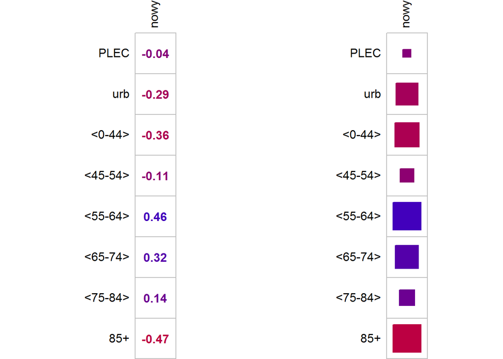

```r
par(mfrow=c(1,2))
corrplot(corelation,col=col3(100),method="number", cl.pos="n",tl.col = "black")
corrplot(corelation,col=col3(100),method="square", cl.pos="n",tl.col = "black")
```

Najwyższą korelacją z liczbą wystąpień nowotworu charakteryzują się urbanizacja oraz zmienne koreślające niektóre przedziały wiekowe. Spodziewamy się zatem, że to one będą miały największy wpływ w prognozie modelu.

Postanowiłyśmy także obliczyć korelację pomiędzy pozostałymi zmiennymi, aby upewnić się, że nie są od siebie silnie zależne.

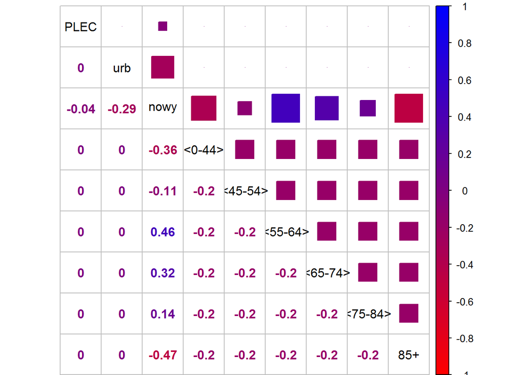

```r
corelation2<-cor(dane_pred)

corrplot.mixed(corelation2,upper="square",lower="number",col=col3(100),tl.col = "black")
```

# Analiza różnych modeli

Do przeprowadzenia analizy postanowiłyśmy wykorzystać metodę walidacji krzyżowej. Pozwala ona lepiej ocenić trafność prognostyczną modelu, niż zwykły podział na próbę testową i uczącą.

## Regresja liniowa

```r
mse_lm <- function(){
    smpl <- createDataPartition(dane_pred$nowy, p=0.8)[[1]]
    train <- dane_pred[smpl,]
    test <- dane_pred[-smpl,]
    model_lm <- lm(nowy~.,data=train)
    return(mse(test$nowy,predict(model_lm, newdata=test)))
}

#mse_lm()
```

## Model ridge

```r
mse_ridge <- function(){
    smpl <- createDataPartition(dane_pred$nowy, p=0.8)[[1]]
    train <- dane_pred[smpl,]
    test <- dane_pred[-smpl,]
    model_ridge <- cv.glmnet(as.matrix(train[,-3]),as.matrix(train$nowy), alpha=0)
    p <-predict(model_ridge,newx=as.matrix(test[,-3]))
    return(mse(p,as.matrix(test$nowy)))
}

#mse_ridge()
```

## Model lasso

```r
mse_lasso <- function(){
    smpl <- createDataPartition(dane_pred$nowy, p=0.8)[[1]]
    train <- dane_pred[smpl,]
    test <- dane_pred[-smpl,]
    model_lasso <- cv.glmnet(as.matrix(train[,-3]),as.matrix(train$nowy))
    p <-predict(model_lasso,newx=as.matrix(test[,-3]))
    return(mse(p,as.matrix(test$nowy)))
}

#mse_lasso()
```

## Klasyfikacja lda

```r
mse_lda<-function() {
  smpl <- createDataPartition(dane_pred$nowy, p=0.8)[[1]]
    train <- dane_pred[smpl,]
    test <- dane_pred[-smpl,]

    classification_lda<-lda(nowy~.,data=train)
    p<-predict(classification_lda,newdata=test[,-3])$class
    predi<-as.numeric(as.vector(p))

    return(mse(as.matrix(predi),as.matrix(test$nowy)))

}

#mse_lda()
```

## Naive Bayes

```r
mse_Bayes<-function() {
  smpl <- createDataPartition(dane_pred$nowy, p=0.8)[[1]]
    train <- dane_pred[smpl,]
    test <- dane_pred[-smpl,]

    classification_Bayes<-naiveBayes(as.factor(nowy)~.,data=train)
    p<-predict(classification_Bayes,test[,-3])
    predi<-as.numeric(as.vector(p))

   return(mse(predi,as.matrix(test$nowy)))
}

#mse_Bayes()
```

## Random forest

```r
mse_rf<-function() {
  smpl <- createDataPartition(dane_pred_temp$V3, p=0.8)[[1]]
    train <- dane_pred_temp[smpl,]
    test <- dane_pred_temp[-smpl,]

    classification_rf<-randomForest(V3~.,data=train,ntree=20)
    prediction<-predict(classification_rf,newdata=test[,-3])

    return(mse(prediction,test$V3))
}

#mse_rf()
```

## Porównanie MSE wszystkich metod

Funkcję skonstruowaną powyżej wywołałyśmy 100 razy, w celu obliczenia błędu MSE dla każdej metody. Wyniki powyższej operacji przedstawione są na poniższym wykresie:

```r
wynik_lm<-data.frame(replicate(100, mse_lm()))

wynik_ridge<-data.frame(replicate(100, mse_ridge()))

wynik_lasso<-data.frame(replicate(100, mse_lasso()))

wynik_lda<-data.frame(replicate(100, mse_lda()))

wynik_Bayes<-data.frame(replicate(100, mse_Bayes()))

wynik_rf<-data.frame(replicate(100, mse_rf()))

wynik_total<-bind_rows(wynik_lm,wynik_ridge,wynik_lasso,wynik_lda,wynik_Bayes,wynik_rf)
```

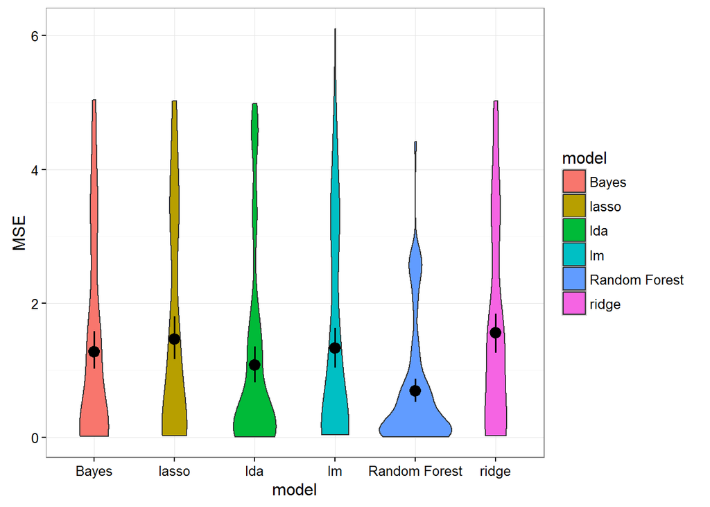

```r
ggplot(wynik_total,aes(x=model,MSE))+geom_violin(aes(fill=model))+ stat_summary(fun.data = "mean_cl_boot", colour = "black", size = 0.7)+theme_bw()
```

Na wykresie widać, że metoda Random Forest osiąga niższe błędy niż pozostałe metody, dlatego tą metodę wybrałyśmy do predykcji.

# Wybrany model - Random Forest

```r
model_probny<-randomForest(V3~.,data=dane_pred_temp,ntree=200)
save(model_probny,file = "model_probny.rda")
```

W celu dopasowania liczby drzew postanowiłyśmy sprawdzić jak kształtuje się błąd w zależności od wybranej liczby.

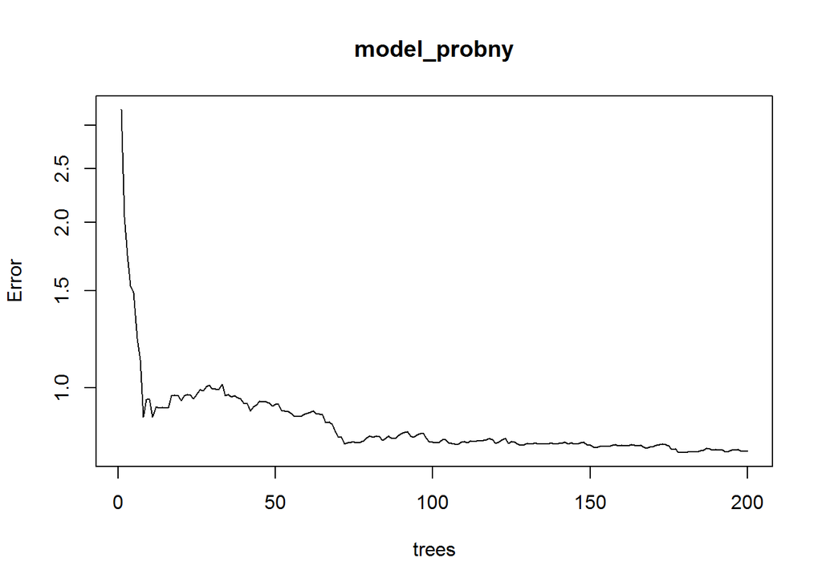

```r
plot(model_probny, log="y")
```

```r
model_rf<-randomForest(V3~.,data=dane_pred_temp,ntree=100,importance = TRUE)
```

Sprawdźmy ważność zmiennych:

```r
var_imp<-varImp(model_rf, useModel="randomForest", numTrees=100)
```

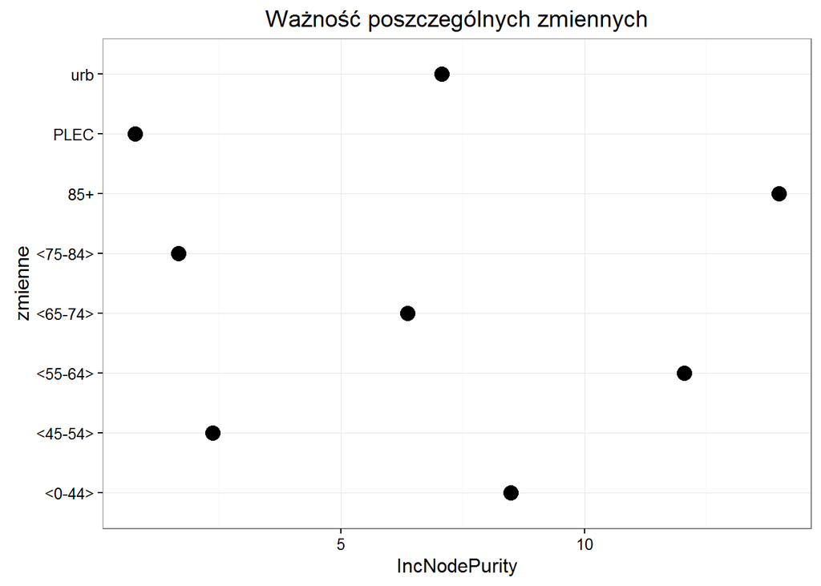

```r
imp <- importance(model_rf, class = NULL, scale = TRUE, type = 2)
ggplot(imp,aes(x=IncNodePurity,y=zmienne))+geom_point(size=4)+ggtitle("Ważność poszczególnych zmiennych")+theme_bw()
```

```r
var_imp
```

```
##           Overall
## PLEC     8.900323
## urb     17.146100
## <0-44>  13.151947
## <45-54> 10.036835
## <55-64> 11.713448
## <65-74> 10.236002
## <75-84>  7.419758
## 85+     13.920051
```

Widzimy, że znaczenie mają poziom urbanizacji miejsca zamieszkania oraz zmienne określające przynależność do niektórych przedziałów wiekowych.

# Predykcja danych

Robimy predykcję dla każdej kombinacji TERYT-wiek-Płeć:

Tworzymy zbiór danych zawierający każdą możliwą kombinację:

```r
grid <- expand.grid(TERYT4=unique(dane_u$TERYT4),PLEC=c("K","M"), grupa_wiek=unique(dane_u$grupa_wiek))
```

Dodajemy do niego urbanizację, którą uwzględniamy przy predykcji:

```r
grid<-left_join(grid,urb_temp)
head(grid)
```

```
##   TERYT4 PLEC grupa_wiek  urb
## 1    201    K     <0-44> 4865
## 2    202    K     <0-44> 8139
## 3    203    K     <0-44> 7915
## 4    204    K     <0-44> 4224
## 5    205    K     <0-44> 5715
## 6    206    K     <0-44> 4807
```

Musimy jeszcze przerobić dane na takie, które będzie w stanie przeczytać nasz model:

```r
head(grid_rf)
```

```
##   TERYT4 PLEC  urb <0-44> <45-54> <55-64> <65-74> <75-84> 85+
## 1    201    0 4865      0       1       0       0       0   0
## 2    201    0 4865      0       0       1       0       0   0
## 3    201    0 4865      0       0       0       1       0   0
## 4    201    0 4865      0       0       0       0       1   0
## 5    201    0 4865      1       0       0       0       0   0
## 6    201    0 4865      0       0       0       0       0   1
```

Przechodzimy do predykcji naszym nauczonym modelem

```r
prediction<-predict(model_rf,newdata=grid_rf[,-1])
predi<-grid
predi$prediction<-prediction
head(predi)
```

```
##   TERYT4 PLEC grupa_wiek  urb prediction
## 1    201    K     <0-44> 4865 0.19349931
## 2    202    K     <0-44> 8139 0.37472514
## 3    203    K     <0-44> 7915 0.34047306
## 4    204    K     <0-44> 4224 0.27150485
## 5    205    K     <0-44> 5715 0.11554948
## 6    206    K     <0-44> 4807 0.08743729
```

Na początku unormowałyśmy dane, zatem uzyskane wyniki predykcji należy z powrotem przeliczyć na ilość nowych przypadków nowotworu, uwzględniając ludność poszczególnych powiatów.

```r
predi<-left_join(predi,Dane_GUS)
predi$prediction<-predi$ludnosc*predi$prediction/1000
```

Zobaczmy ostateczny wynik predykcji

```r
head(wynik)
```

```
##   TERYT4 PLEC grupa_wiek prediction
## 1    201    K     <0-44>  17.481888
## 2    202    K     <0-44>  38.999519
## 3    203    K     <0-44>  30.718160
## 4    204    K     <0-44>   9.838250
## 5    205    K     <0-44>   5.985001
## 6    206    K     <0-44>   5.680713
```

Zobaczmy, jak nasza predykcja rozkłada się na mapie Polski:

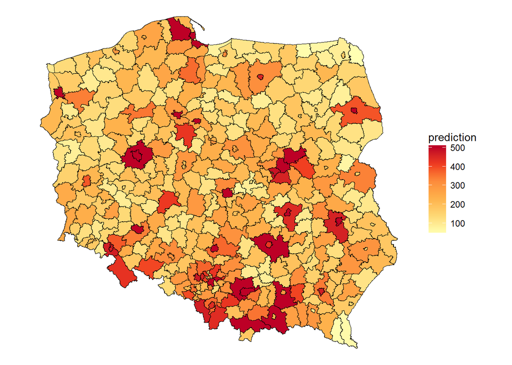

```r
ggplot() + geom_polygon(data = wynik_mapka2, aes(x = long, y = lat, group = group, fill = prediction), color = "black", size = 0.25)+coord_equal(ratio=1)+scale_fill_distiller(palette = "YlOrRd",direction=1)+ylab("")  + xlab("")+theme_nothing(legend=TRUE)
```